# Analysis of Capital Bikeshare Bike Ride

# Introduction

Due to increasing volume of traffic in the cities, commuting has become a very tedious task. Additionally, vehicles running on fossil fuel have massive carbon footprints which adversely affect the environment. Therefore, people have started looking at alternate commuting methods to such as bicycles. Rental bike services, Capital Bikeshare have become hugely popular in the United States. The analysis of the data from Capital Bikeshare will help in understanding the trend of the usage of such services. Also, it will help in improving the service.

```r
data_cleaned <- tibble()

#Removing existing duration column as it will be later calculated from the start date and end date in the column
data_cleaned <- select(rides_raw, -Duration)


#Merging common variables

data_cleaned %>%
  mutate(starting_date = coalesce(`Start date` , `started_at`)) %>%
  mutate(end_date = coalesce(`End date` , `ended_at`)) %>%
  mutate(end_station = coalesce(`End station` , `end_station_name`)) %>%
  mutate(start_station = coalesce(`Start station` , `start_station_name`)) %>%
  mutate(member_type = coalesce(`Member type`, `member_casual`)) -> data_cleaned
```

```r
data_final <- tibble()
data_final <- select(data_cleaned, -(which(names(rides_raw) %in% names(data_cleaned))-1)) #Removing redundant columns

data_final %>%
  mutate(duration = as.duration(end_date - starting_date)) ->  data_final

data_final %>% mutate(end_station = as.factor(end_station)) %>% mutate(start_station = as.factor(start_station)) %>% mutate(member_type = as.factor(member_type)) -> data_final

data_final$member_type <- fct_recode(data_final$member_type, casual = "Casual", member = "Member") #renaming the factors generalize throughout the data
```

# Data

The data used in this analysis has been collected from “https://www.capitalbikeshare.com/system-data”. The data gives the details of trip history of the rides taken between January, 2019 to July, 2020.

The data collected from the aforementioned source includes:

- Starting_date : Gives time and date when the ride started
- End_date : Gives time and date when the ride ended
- Duration : provides duration of the ride
- Start_station : provides the name of the starting station
- End_station: provides the name of the destination

```r
data_final %>% filter(duration > 0) -> data_final
data_final <- data_final[c("starting_date", "end_date", "duration", "start_station", "end_station", "member_type")]
```

# Questions

**How long do people use the bike for?**

*Operationalisation:* Duration vs. Count of rides taken. The plot between he duration and rides taken and the count for ride for the duration will give the result for how much time on a daily basis do the people usually prefer to avail the ride services.

**What is the relation between the type of membership and the duration of the ride availed?**

*Operationalisation:* Number of rides and duration for which ride availed for each membership type.

**How the demand has changed from 2019 to mid of 2020?**

*Operationalisation:* Count of rides availed in each month from begning of 2019 to mid of 2020.

**How frequency of rides vary from the weekend to weekdays?**

*Operationalisation:* Check count of rides for weekdays and weekends.

**Through out the week, at what time of the day the bike rides are used the most? Is there a pattern between the time of the day and the number of rides taken?**

*Operationalisation:* Check the number of rides taken during the hour of the day through the entire week.

# Analysis

### How long do people use the bike ride for?

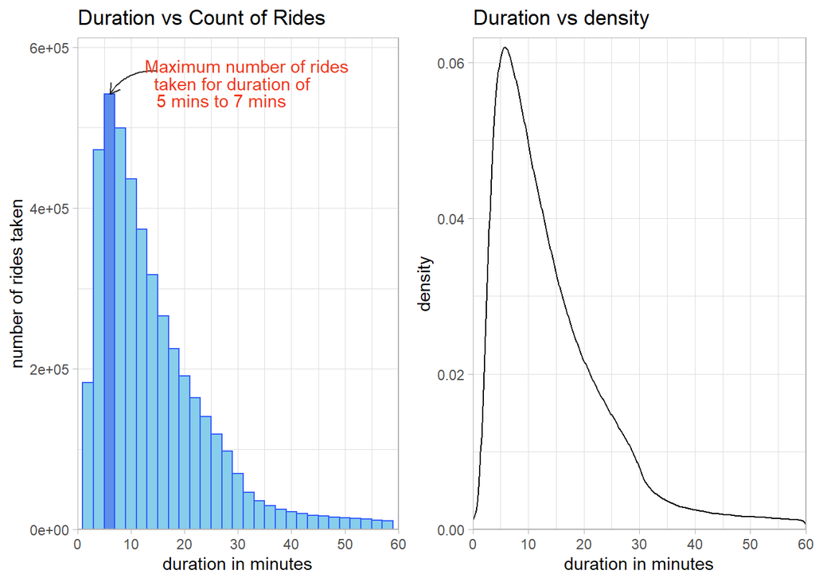

```r
#Histogram to show relation between duration and number of rides
p1 <-  ggplot(data_final) +
  geom_histogram(mapping = aes(x = (duration / 60),) , fill = "#87ceeb", color = "#335DFF", binwidth = 2) +
  scale_x_continuous(limits = c(0,60), expand = c(0,0)) +
  labs(x = "duration in minutes", y = "number of rides taken", title = "Duration vs Count of Rides") + scale_y_continuous(expand = expansion(mult = c(0, 0.02))) + coord_cartesian(ylim = c(0, 6e+05)) +
  annotate(geom  = "rect", xmin  = 5, xmax  = 7, ymin  = 0, ymax  = 5.42e+05,alpha = 0.4, fill  = "#212EEB") +
  annotate(geom = "curve", x = 15, y = 5.7e+05, xend = 6, yend = 5.42e+05, curvature = 0.3, arrow = arrow(length = unit(2.5, "mm")),alpha = 0.8) +
  annotate(geom = "text", x = 16.4, y = 5.2e+05, label = "Maximum number of rides\n taken for duration of\n 5 mins to 7 mins", hjust = 0.1, vjust = -0.1, lineheight = 0.8, color = "#F0371B") + theme_light()

#Density distribution graph
p2 <- ggplot(data_final) + geom_density(mapping = aes(x = (duration / 60)))+scale_x_continuous(limits = c(0,60), expand = c(0,0)) + labs(x = "duration in minutes", y = "density", title = "Duration vs density") + scale_y_continuous(expand = expansion(mult = c(0, 0.02))) + theme_light()

#Show both graphs side by side
grid.arrange(p1, p2, nrow = 1)
```

The above graphs show that most people prefer to rent the ride for about 5 to 10 minutes. Which means, people usually prefers bike ride for traveling comparatively shorter distance.

### What is the relation between the type of membership and the duration of the ride availed?**

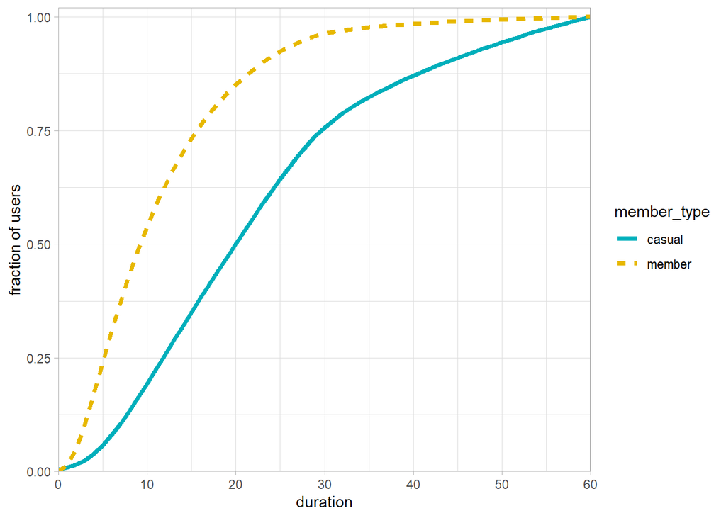

```r
library(ggpubr)
library("arules")

data_final %>% mutate(duration = duration / 60) %>%
  mutate(duration = as.integer(duration)) -> df
a <- ggplot(df, mapping = aes(x = duration)) + scale_x_continuous(limits = c(0,60), expand = c(0,0))

a + stat_ecdf(aes(color = member_type,linetype = member_type),
              geom = "line", size = 1.5) +
  scale_color_manual(values = c("#00AFBB", "#E7B800"))+
  labs(y = "fraction of users") + scale_y_continuous(expand = expansion(mult = c(0, 0.02))) + theme_light()
```

The above graph shows the trend for the duration of bike rides by members and casual users. It is clear form the above distribution curve that the members tend to avail the shorter ride than the casual riders. This can be attributed to the fact that the members under a particular plan, for example “Daily” or “Monthly” plans can avail the rides for unlimited number of times during the span of their subscription to the service. Hence, even for smaller distance, they prefer to avail the ride as the rides are already prepaid. However, the casual users have to pay per ride, hence, the the ride only for the greater distances i.e only when it is necessary and the longer duration.

### How the demand has changed from 2019 to mid of 2020?

To assess this, we will have look at plot of number of rides taken each month starting from January 2019 to July 2020.

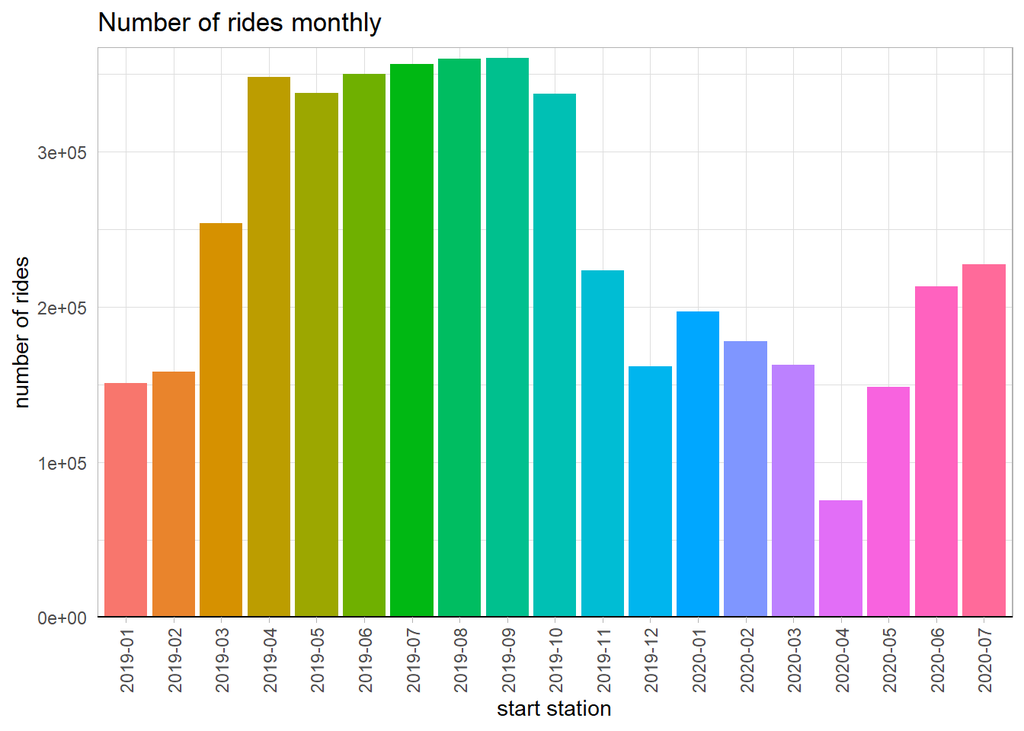

```r
data_final %>%
  mutate(starting_date = format(as.Date(starting_date), "%Y-%m")) -> temp_data

temp_data <- temp_data[order(temp_data$starting_date),]
temp_data %>% group_by(starting_date) %>% count() %>% ggplot(aes(x = starting_date, y = n, fill = starting_date), show.legend = FALSE) + geom_bar(stat = "identity", show.legend = FALSE) +
  labs(x = "start station", y = "number of rides", title = "Number of rides monthly")  + scale_y_continuous(expand = expansion(mult = c(0, 0.02))) + theme_light() +
  theme(
    axis.line.y  = element_blank(),
    axis.line.x  = element_line(colour = "black"),
    axis.ticks.y = element_blank(),
    axis.text.x  = element_text(
                     angle = 90,
                     hjust = 1,
                     vjust = 0.5
                   )
  )
```

### How density of rides vary from the weekend to weekdays?

To check this we will compare the density curve of duration for the rides taken during weekdays and weekends.

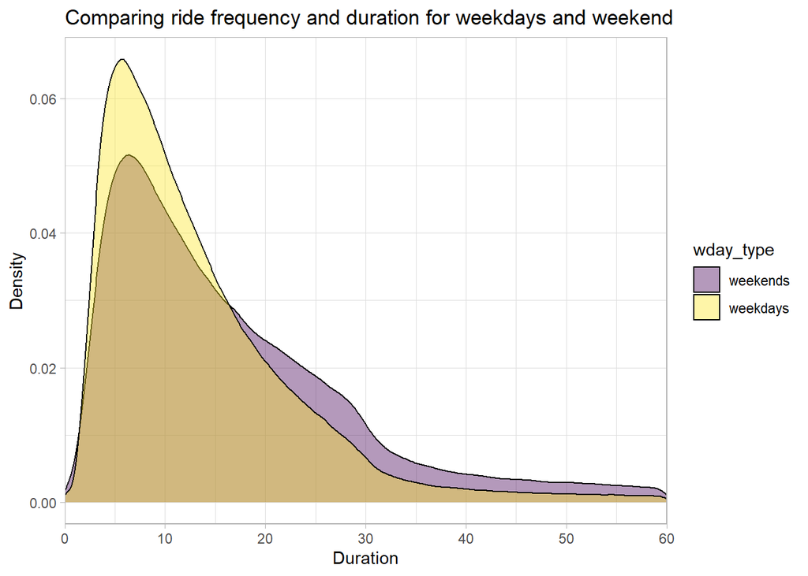

```r
#Creating new column for days of the week
data_final %>% mutate(week_day = wday(data_final$starting_date, label = TRUE)) %>% mutate(week_day = as.factor(week_day)) -> data_wd

#Creating new column to classify the days in weekdays and weekend
data_wd %>% mutate(wday_type = fct_recode(data_wd$week_day, "weekdays" = "Mon", "weekdays" = "Tue", "weekdays" = "Wed", "weekdays" = "Thu", "weekdays" = "Fri", "weekends" = "Sat", "weekends" = "Sun")) -> data_wd

#Density plot
data_wd %>% ggplot() + geom_density(mapping = aes(x = (duration / 60), fill = wday_type), alpha = 0.4) + scale_x_continuous(limits = c(0,60), expand = c(0,0)) + labs(x = "Duration", y = "Density", title = "Comparing ride frequency and duration for weekdays and weekend") + theme_light()
```

### Through out the week, at what time of the day the bike rides are used the most? Is there a pattern between the time of the day and the number of rides taken?

To answer the above question, we will have a look at the heat map of the hour vs. the duration of the ride on each day of the week.

```r
#Extracting hour from the date
data_test <- data_wd %>% mutate(start_time = round(as.POSIXlt(starting_date, format = "%Y%m%d %H:%M:%S", tz = "UTC"), units = "hours")) %>% mutate(start_time = format.Date(start_time,  "%H:%M:%S")) %>% mutate(start_time = as.factor(start_time))
```

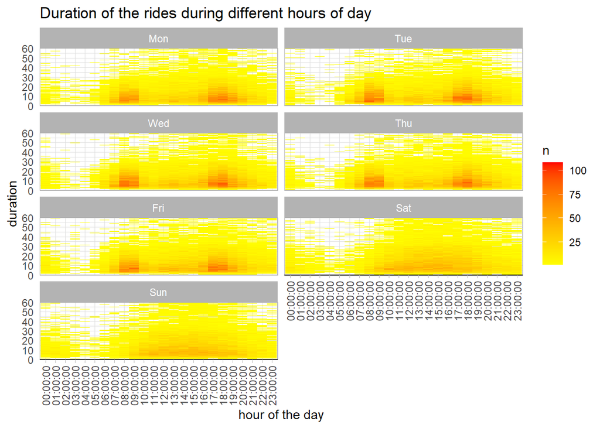

```r
#Plotting the heat map
data_test2 <- data_test %>%
  mutate(week_day = factor(week_day, levels = c("Mon","Tue", "Wed", "Thu", "Fri", "Sat", "Sun" ))) %>%
  group_by(duration, week_day, start_time) %>%
  summarize(n = n())
 ggplot(data_test2, aes(start_time, duration/60, fill = n)) +
  geom_tile() + labs(x = "hour of the day", y = "duration", title = "Duration of the rides during different hours of day")+
  scale_y_continuous(limits = c(0,60), expand = c(0,0)) + scale_fill_gradient2(low = "green", mid = "yellow", high = "red", na.value = NA) + facet_wrap(~week_day, ncol = 2) +
   theme_light() +
  theme(
    axis.line.y  = element_blank(),
    axis.line.x  = element_line(colour = "black"),
    axis.ticks.y = element_blank(),
    axis.text.x  = element_text(
                     angle = 90,
                     hjust = 1,
                     vjust = 0.5
                   )
  )
```

From the above graphs it can be observed that the rides are most frequently used during the weekdays during 8 a.m to 10 a.m in the morning and 5 p.m to 7 p.m in the evening. This is the peak hour for people to get to work and return from the work. From this it can be concluded that during the weekdays the ride service is mostly used for commuting to and from work places. As opposed to this the most frequent use of rides during the weekends is between 9 am to 7pm. Although the frequency of ride is less but the duration is spread evenly through out this period.

## Conclusion

Following are the kew takeaways from the above analysis: